# Praca domowa 3

2023-03-23

# Jan Kwiecień

## **1. Wstęp**

W ramach pracy domowej numer trzy mieliśmy za zadanie przygotować eksperyment, sprawdzający czytanie danych z wykresów skonstruowanych prawidłowo oraz wbrew “dobrym praktykom”.

Ja postanowiłem sprawdzić różnice w odczycie informacji z wykresu słupkowego oraz kołowego. Przedstawiają one zmyślony procentowy rozkład kwiatów na pewnej łące. Przyjrzyjmy im się bliżej.

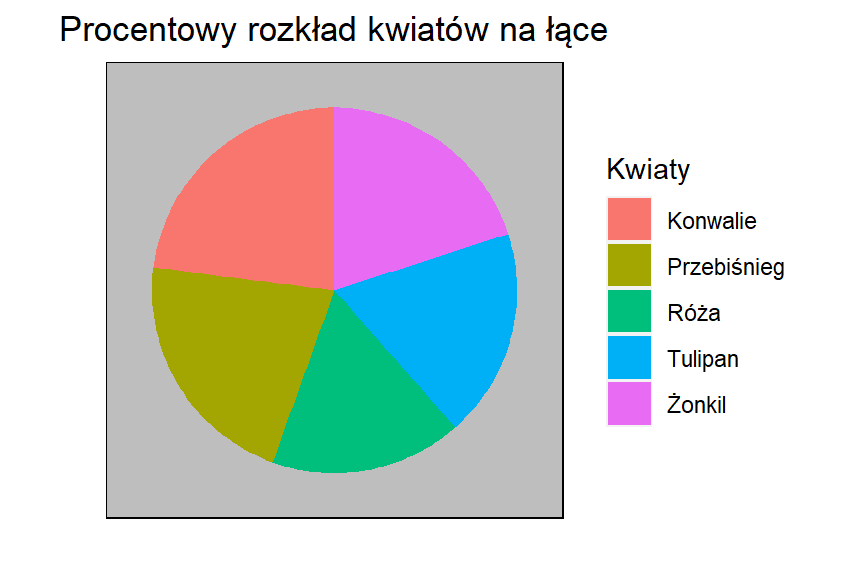

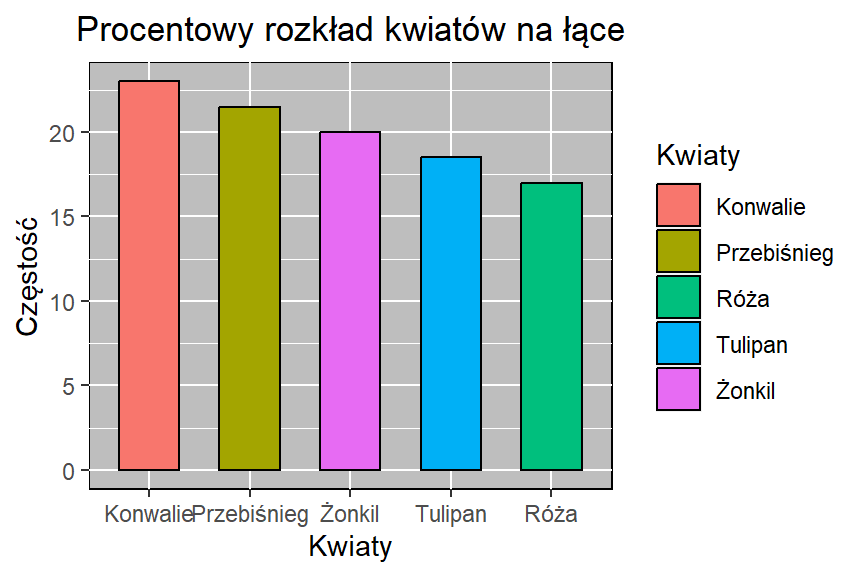

## **2. Przeprowadzenie eksperymentu**

Oba wykresy przedstawiają ten sam rozkład. Z zajęć wiemy, że dane przedstawione na wykresie kołowym najczęściej sprawdzają się gorzej niż te na kolumnowym (brak punktu odniesienia). W tym celu przeprowadziłem eksperyment, w którym piętnastu ankietowanych (w wieku 20 - 21 lat) poproszonych było o ułożenie w kolejności rosnącej ilości występowania poszczególnych kwiatów.

## **3. Wyniki**

W przypadku wykresu kolumnowego wszyscy ankietowani odpowiedzieli w sposób prawidłowy. Rozbieżności zaczęły się pojawiać w przypadku diagramu kołowego. Tabela poniżej prezentuje posczególne odpowiedzi.

```
##                   osoby najmnniej czwarty      trzeci       drugi   najwięcej prawidłowe_przyporządkowanie
## 1  prawidłowa_kolejność      Róża Tulipan      Żonkil Przebiśnieg    Konwalie                            -
## 2                     1      Róża Tulipan      Żonkil Przebiśnieg    Konwalie                          TAK
## 3                     2      Róża Tulipan      Żonkil    Konwalie Przebiśnieg                          NIE
## 4                     3      Róża  Żonkil     Tulipan Przebiśnieg    Konwalie                          NIE
## 5                     4      Róża Tulipan      Żonkil Przebiśnieg    Konwalie                          TAK
## 6                     5      Róża  Żonkil     Tulipan    Konwalie Przebiśnieg                          NIE
## 7                     6   Tulipan    Róża      Żonkil    Konwalie Przebiśnieg                          NIE
## 8                     7      Róża Tulipan      Żonkil    Konwalie Przebiśnieg                          NIE
## 9                     8      Róża Tulipan      Żonkil Przebiśnieg    Konwalie                          TAK
## 10                    9      Róża Tulipan      Żonkil Przebiśnieg    Konwalie                          TAK
## 11                   10   Tulipan    Róża Przebiśnieg      Żonkil    Konwalie                          NIE
## 12                   11      Róża Tulipan      Żonkil Przebiśnieg    Konwalie                          TAK
## 13                   12      Róża Tulipan Przebiśnieg      Żonkil    Konwalie                          NIE
## 14                   13   Tulipan  Żonkil        Róża Przebiśnieg    Konwalie                          NIE
## 15                   14      Róża Tulipan      Żonkil Przebiśnieg    Konwalie                          TAK
## 16                   15      Róża Tulipan      Żonkil Przebiśnieg    Konwalie                          TAK
```

Na 15 ankietowanych jedynie 7 osób podało prawidłową odpowiedź. Pozostali najczęściej mylili się zamieniając kolejnością dwa wyniki znajdujące się obok siebie. Działo się tak między innymi w przypadku: Konwalii i Przebiśniegów czy Żonkili i Tulipanów. Dodatkowo w błąd mogła wprowadzać kolejność kolorów (nie były one ułożone tak jak standardowa paleta).

## **4. Wnioski**

Rzeczywiście, metody omówione podczas zajęć okazały się być prawdziwe w przełożeniu na rzeczywistość. Badanie to pokazało przewagę wykresów kolumnowych nad kołowymi.